# SOAK Census 2024

This document was created by Amanda “Tuna” Welch, M.S. Contributions made by Tracy Mehoke in Residence section.

All data was collected on site between May 22 and May 24, 2024 by sampling vehicles upon entry. A total of 941 surveys were collected. Box Office recorded 2,328 tickets used for entry.

Data was input by volunteers into Qualtrics and raw numbers were downloaded for analysis.

Analysis and visualization done in R and RStudio. RStudio Team (2022). RStudio: Integrated Development Environment for R. RStudio, PBC, Boston, MA URL http://www.rstudio.com/.

Code and data available on Github at https://github.com/amcowelch/SOAK-Census

For questions or comments: census@soakpdx.com or tuna@soakpdx.com

# Attendance

### Previous Years Attended

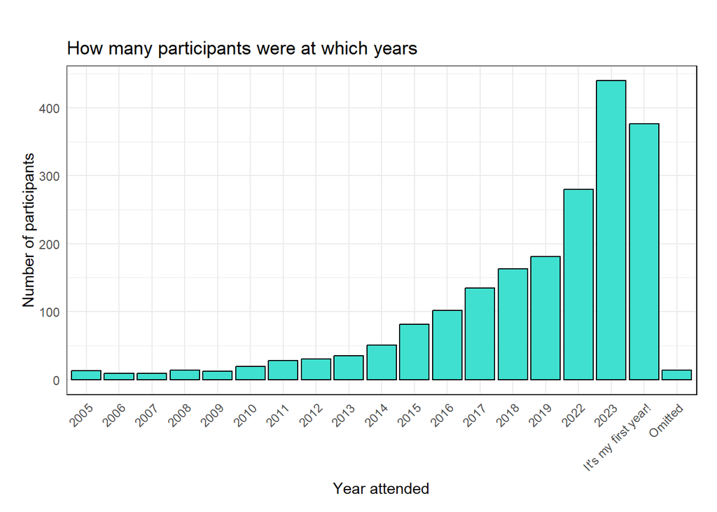

Were you there in 2008? What about last year? While only 14 surveyed folks were at 2008 SOAK, a total of 376 participants (40.6% of participants) reported 2024 as their first time attending SOAK, which is a decrease from 2023 which had 43.2% of the population report themselves as first timers. In 2023, Burning Man’s population of first timers was 43.9% [according to their Census report](https://blackrockcitycensus.org/sociodemo).

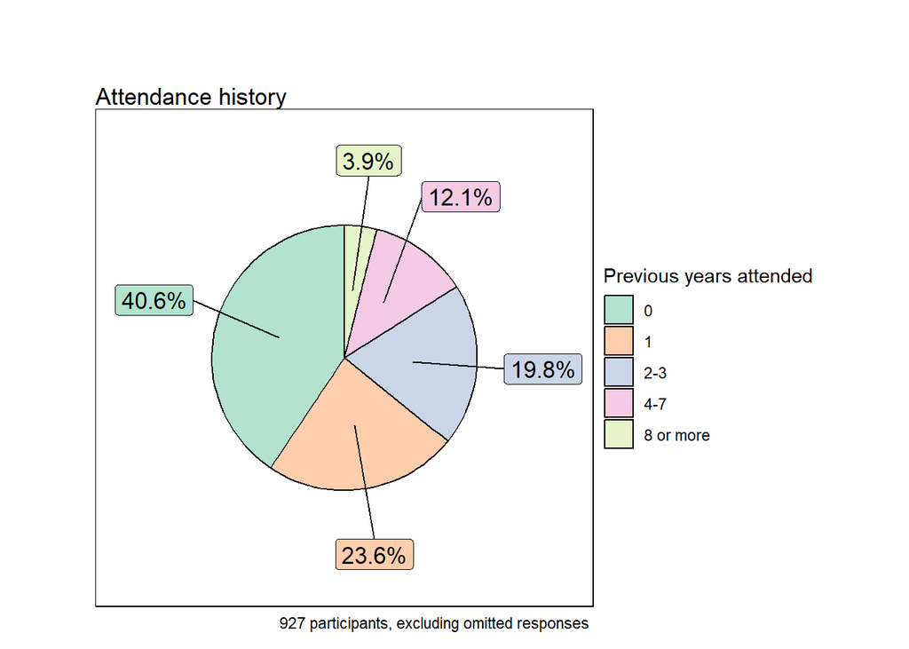

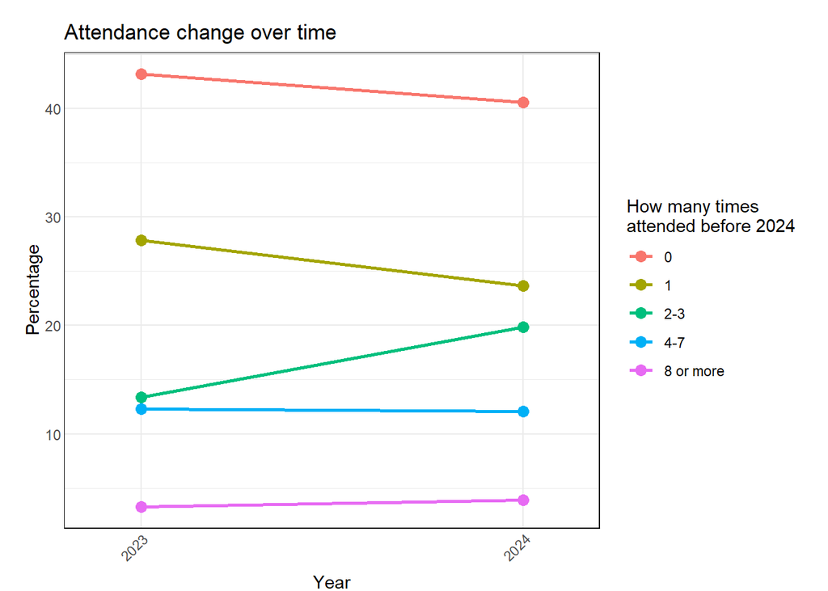

Here we see the total percent of participants who were first timers compared to returning for 1, 2 to 3, 4 to 7, or 8+ times. The line plot demonstrates the changes in each attendance category over one year.

How many years have you attended SOAK?

| Previous years attended | 2023 Count | 2023 Percent | 2024 Count | 2024 Percent |
| --- | --- | --- | --- | --- |
| 0 | 287 | 43.2 | 376 | 40.6 |
| 1 | 185 | 27.8 | 219 | 23.6 |
| 2-3 | 89 | 13.4 | 184 | 19.8 |
| 4-7 | 82 | 12.3 | 112 | 12.1 |
| 8 or more | 22 | 3.3 | 36 | 3.9 |

[According to the Burning Man Census Report](https://blackrockcitycensus.org/), its population had 28.3% first-time burners in 2022, with an increase to 43.9% first-timers in 2023, in comparison to SOAK’s 43.2% fist-time SOAKers in 2023 and a slight decrease to 40.6% in 2024.

# Sociodemographic Characteristics

## Age and Gender

### Age

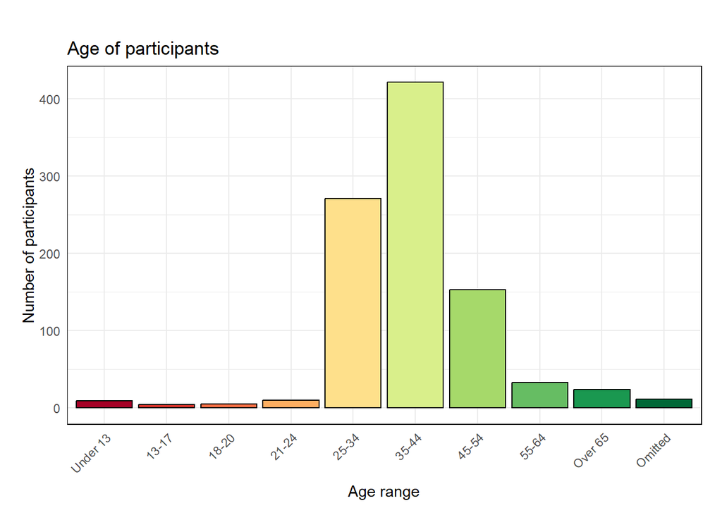

Age range

| 2023 Age group | 2023 Count | 2023 Percent | 2024 Age group | 2024 Count | 2024 Percent |
| --- | --- | --- | --- | --- | --- |
| Under 13 | 7 | 1.0 | Under 13 | 9 | 1.0 |
| 13-17 | 7 | 1.0 | 13-17 | 4 | 0.4 |
| NA | NA | NA | 18-20 | 5 | 0.5 |
| 18-24 | 12 | 1.8 | 21-24 | 10 | 1.1 |
| 25-34 | 238 | 35.5 | 25-34 | 271 | 28.8 |
| 35-44 | 260 | 38.8 | 35-44 | 421 | 44.7 |
| 45-54 | 97 | 14.5 | 45-54 | 153 | 16.3 |
| 55-64 | 26 | 3.9 | 55-64 | 33 | 3.5 |
| Over 65 | 15 | 2.2 | Over 65 | 24 | 2.6 |
| Omitted | 8 | 1.2 | Omitted | 11 | 1.2 |

In 2024, the majority of participants were between ages 25 and 44. Ages 35-44 were the highest reported age. Most age groups remained similar from 2023 to 2024, but there was a decrease in participants ages 25-34, increase in participants in ages 35-44, and an increase in participants ages 45-54.

The survey changed from 2023 to 2024, by breaking the 18-24 age group into 2 subets: 18-20 and 21-24, thus we do not have an exact comparison for these ranges from year to year.

When compared to [the Burning Man Census Report](https://blackrockcitycensus.org/sociodemo#age),in 2023 the age of 36 is in the 50th percentile of ages. Between SOAK and the big burn, our age groups are distributed similarly.

### Gender Identity

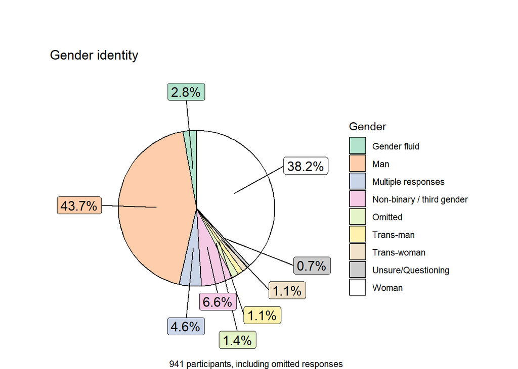

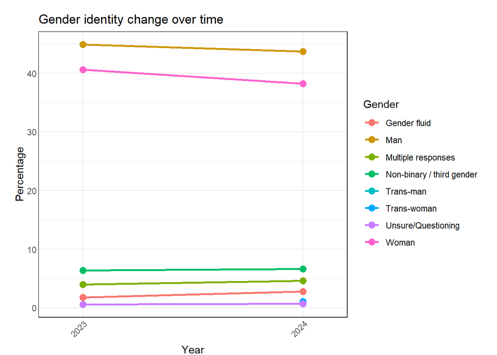

Most reported genders were stable between 2023 and 2024. In 2024, we added the option to select trans-man and trans-woman, which accounted for 2.2% of all participants. Men accounted for most participants at 43.7%, followed by women at 38.2%.

Gender identity

| 2023 Gender | 2023 Count | 2023 Percent | 2024 Gender | 2024 Count | 2024 Percent |
| --- | --- | --- | --- | --- | --- |
| Man | 301 | 44.9 | Man | 411 | 43.7 |
| Woman | 272 | 40.6 | Woman | 359 | 38.2 |
| Non-binary / third gender | 43 | 6.4 | Non-binary / third gender | 62 | 6.6 |
| Multiple identities | 27 | 4.0 | Multiple responses | 43 | 4.6 |
| Gender fluid | 12 | 1.8 | Gender fluid | 26 | 2.8 |
| Omitted | 2 | 0.3 | Omitted | 13 | 1.4 |
| Other | 9 | 1.3 | Trans-man | 10 | 1.1 |
| NA | NA | NA | Trans-woman | 10 | 1.1 |
| Unsure/Questioning | 4 | 0.6 | Unsure/Questioning | 7 | 0.7 |

The above table is organized in descending order based on 2024’s Percent column. According to [World Population Review](https://worldpopulationreview.com/state-rankings/transgender-population-by-state), while Oregon in 2024 had a transgender population of 0.47%, SOAK welcomed 2.2% transgender folks.

# Income and Education

### Education

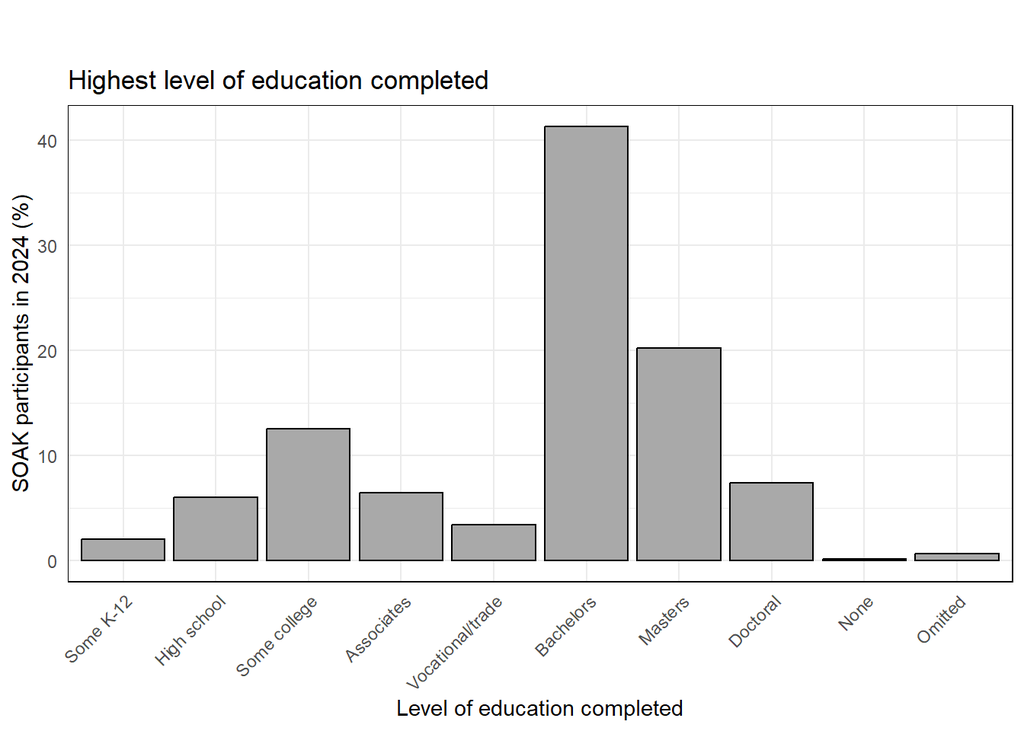

In 2024, the number of advanced degrees (masters, doctoral) increased more than any other category. As our average population age also increased, this advancement in education follows logically.

Educational attainment

| Education | 2023 Count | 2023 Percent | 2024 Count | 2024 Percent |
| --- | --- | --- | --- | --- |
| Some K-12 | 15 | 2.2 | 19 | 2.0 |
| High school (diploma or GED) | 32 | 4.8 | 56 | 6.0 |
| Some college | 94 | 14.0 | 118 | 12.5 |
| Associates | 44 | 6.6 | 60 | 6.4 |
| Vocational/trade | 21 | 3.1 | 32 | 3.4 |
| Bachelors | 288 | 43.0 | 389 | 41.3 |
| Masters | 123 | 18.4 | 190 | 20.2 |
| Doctoral | 42 | 6.3 | 70 | 7.4 |
| None | 1 | 0.1 | 1 | 0.1 |
| Omitted | 10 | 1.5 | 6 | 0.6 |

According to data pulled from the [US Census Bureau](https://fred.stlouisfed.org/graph/?g=1CUwr), in 2023 37.7% of Oregonians attained a Bachelor’s Degree or Higher. In 2023, [49.2% of Burners had Bachelor’s degrees](https://blackrockcitycensus.org/sociodemo#highest-level-of-education-completed).

### Income

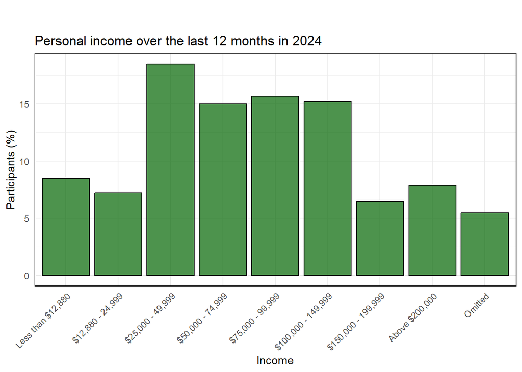

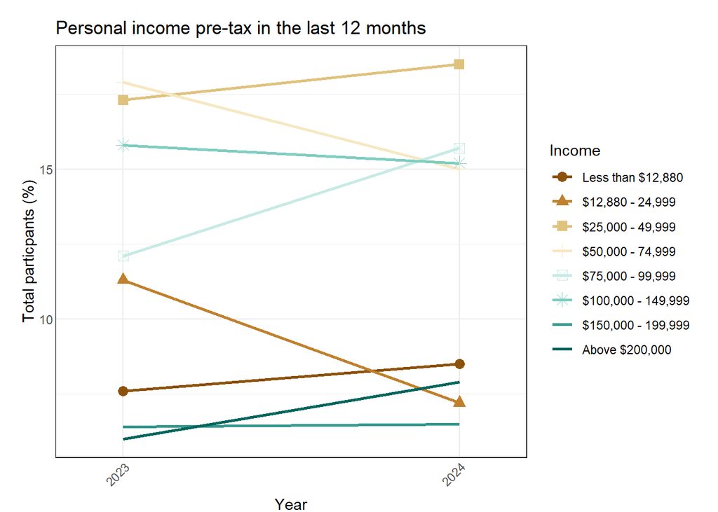

The most commonly reported income in 2024 was $25,000-49,999. The largest change in 2024 was the income bracket of $12,880-24,999, which decreased by 4.1%. The distribution of incomes is fairly even in the middle brackets, with lower values on the tails, as you would expect.

Personal income pre-tax in previous 12 months

| Income | 2023 Count | 2023 Percent | 2024 Count | 2024 Percent |
| --- | --- | --- | --- | --- |
| Less than $12,880 | 51 | 7.6 | 80 | 8.5 |
| $12,880 - 24,999 | 76 | 11.3 | 68 | 7.2 |
| $25,000 - 49,999 | 116 | 17.3 | 174 | 18.5 |
| $50,000 - 74,999 | 120 | 17.9 | 141 | 15.0 |
| $75,000 - 99,999 | 81 | 12.1 | 148 | 15.7 |
| $100,000 - 149,999 | 106 | 15.8 | 143 | 15.2 |
| $150,000 - 199,999 | 43 | 6.4 | 61 | 6.5 |
| Above $200,000 | 40 | 6.0 | 74 | 7.9 |
| Omitted | 37 | 5.5 | 52 | 5.5 |

According to the Oregon Secretary of State, the [per capita personal income in 2023 was $65,426](https://sos.oregon.gov/blue-book/Pages/facts/economy-income.aspx). To calculate the SOAK per capita income, we would need exact income amounts instead of ranges. Despite this, we can see the majority of participants earn within a bracket that would suggest our per capita is similar to or above Oregon.

### Residence

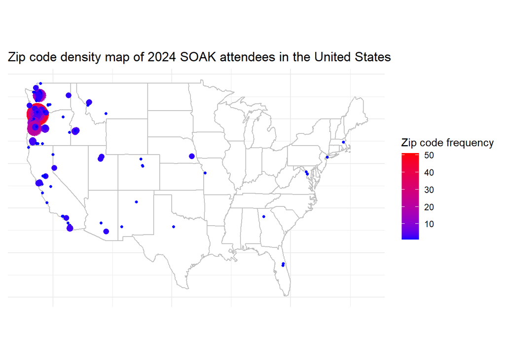

This density heat map shows the highest and lowest concentrations of residencies of SOAK participants. As expected, we see the hottest and largest areas in the Pacific Northwest.

State counts

| 2023 State | 2023 Count | 2023 Percent | 2024 State | 2024 Count | 2024 Percent |
| --- | --- | --- | --- | --- | --- |
| OR | 434 | 70.6 | OR | 630 | 71.3 |
| WA | 118 | 19.2 | WA | 160 | 18.1 |
| CA | 28 | 4.6 | CA | 35 | 4.0 |
| ID | 11 | 1.8 | ID | 14 | 1.6 |
| NY | 4 | 0.7 | Canada | 7 | 0.8 |
| CO | 2 | 0.3 | MT | 6 | 0.7 |
| Germany | 2 | 0.3 | NV | 4 | 0.5 |
| MA | 2 | 0.3 | UT | 4 | 0.5 |
| MO | 2 | 0.3 | AZ | 3 | 0.3 |
| MT | 2 | 0.3 | CO | 3 | 0.3 |
| NV | 2 | 0.3 | FL | 2 | 0.2 |
| France | 1 | 0.2 | MA | 2 | 0.2 |
| GA | 1 | 0.2 | NE | 2 | 0.2 |
| IA | 1 | 0.2 | NM | 2 | 0.2 |
| LA | 1 | 0.2 | VA | 2 | 0.2 |

The top 15 states of origin reported in 2023 and 2024. Oregon, Washington, California, and Idaho were the states most commonly reported. We also have Canada in our top 15 places of origin in 2024.

City counts (top 10)

| 2023 City | 2023 Count | 2023 Percent | 2024 City | 2024 Count | 2024 Percent |
| --- | --- | --- | --- | --- | --- |
| Portland | 307 | 49.9 | Portland | 442 | 50.1 |
| Seattle | 64 | 10.4 | Seattle | 75 | 8.5 |
| Eugene | 42 | 6.8 | Eugene | 60 | 6.8 |
| Vancouver | 16 | 2.6 | Vancouver | 27 | 3.1 |
| Corvallis | 10 | 1.6 | Beaverton | 19 | 2.2 |
| Springfield | 9 | 1.5 | Corvallis | 13 | 1.5 |
| Beaverton | 8 | 1.3 | Boise | 12 | 1.4 |
| Bend | 7 | 1.1 | Salem | 11 | 1.2 |
| Hillsboro | 7 | 1.1 | Bend | 10 | 1.1 |
| Salem | 7 | 1.1 | Hillsboro | 10 | 1.1 |

When looking at specific cities, the top 10 reported were in Oregon, Washington, and Idaho with Portland accounting for just over half (50.1%) of all responses. The top 4 cities have remained the same between 2023 and 2024, with Boise entering the top 10 to include Idaho for the first time.

# Ethnicity and Language

### Ethnicity

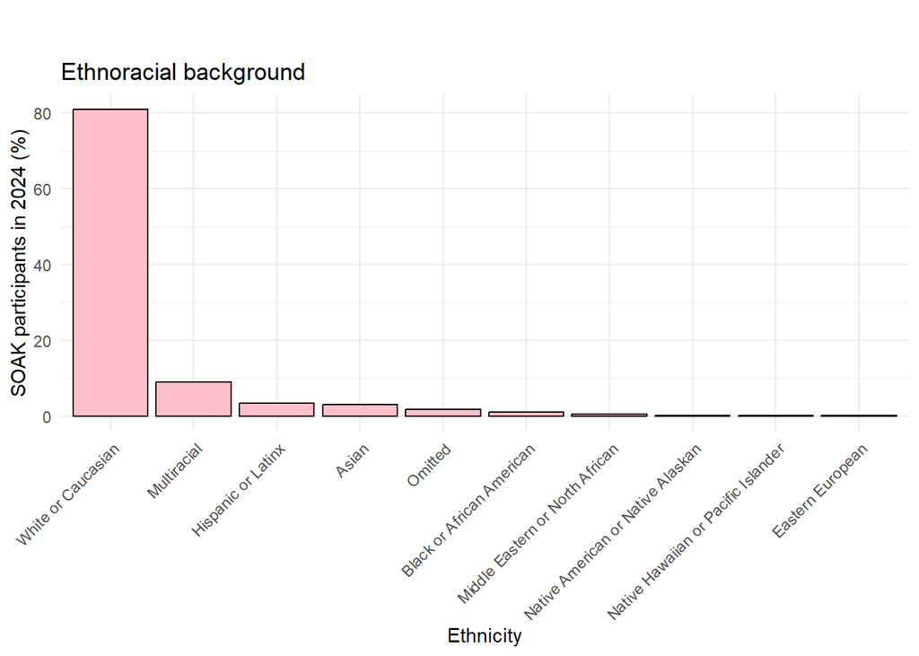

Ethnicity (or race) you identify with

| Race | 2023 Count | 2023 Percent | 2024 Count | 2024 Percent |
| --- | --- | --- | --- | --- |
| White or Caucasian | 518 | 77.3 | 761 | 80.9 |
| Multiracial | 68 | 10.1 | 84 | 8.9 |
| Hispanic or Latinx | 23 | 3.4 | 32 | 3.4 |
| Asian | 20 | 3.0 | 28 | 3.0 |
| Other | 11 | 1.6 | NA | NA |
| Middle Eastern or North African | 10 | 1.5 | 5 | 0.5 |
| Black or African American | 9 | 1.3 | 9 | 1.0 |
| Omitted | 8 | 1.2 | 17 | 1.8 |
| Native Hawaiian or Pacific Islander | 2 | 0.3 | 2 | 0.2 |
| Native American or Native Alaskan | 1 | 0.1 | 2 | 0.2 |
| Eastern European | NA | NA | 1 | 0.1 |

The most common reported race was White or Caucasian, which is the same as in 2023. Generally, the reporting of race was consistent between years with a slight uptick in White.

[According to Data USA](https://datausa.io/profile/geo/oregon#demographics), in 2022 Oregon’s White population was 73.3%. Oregon’s Hispanic population in 2022 was 13.8% compared to SOAK’s 3.4%. Multiracial was categorized by non-Hispanic and Hispanic at 5.2% and 4.01%, respectively. Asian was 4.38% compared to SOAK’s 3%, which was consistent between years.

### Birth Place

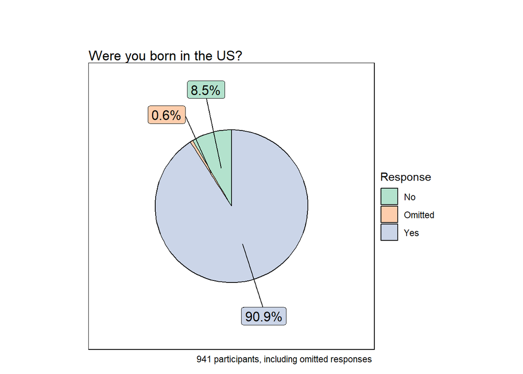

Were you born in the US?

| Response | 2023 Count | 2023 Percent | 2024 Count | 2024 Percent |
| --- | --- | --- | --- | --- |
| No | 61 | 9.1 | 80 | 8.5 |
| Omitted | 14 | 2.1 | 6 | 0.6 |
| Yes | 595 | 88.8 | 855 | 90.9 |

Most participants were born in the USA. In Oregon in 2023, [the foreign-born population was 9.6%](https://usafacts.org/answers/how-many-immigrants-are-in-the-us/state/oregon/) compared to SOAK’s 8.5% foreign-born population in 2024, which was a decrease from 9.1% in 2023.

### Primary Language

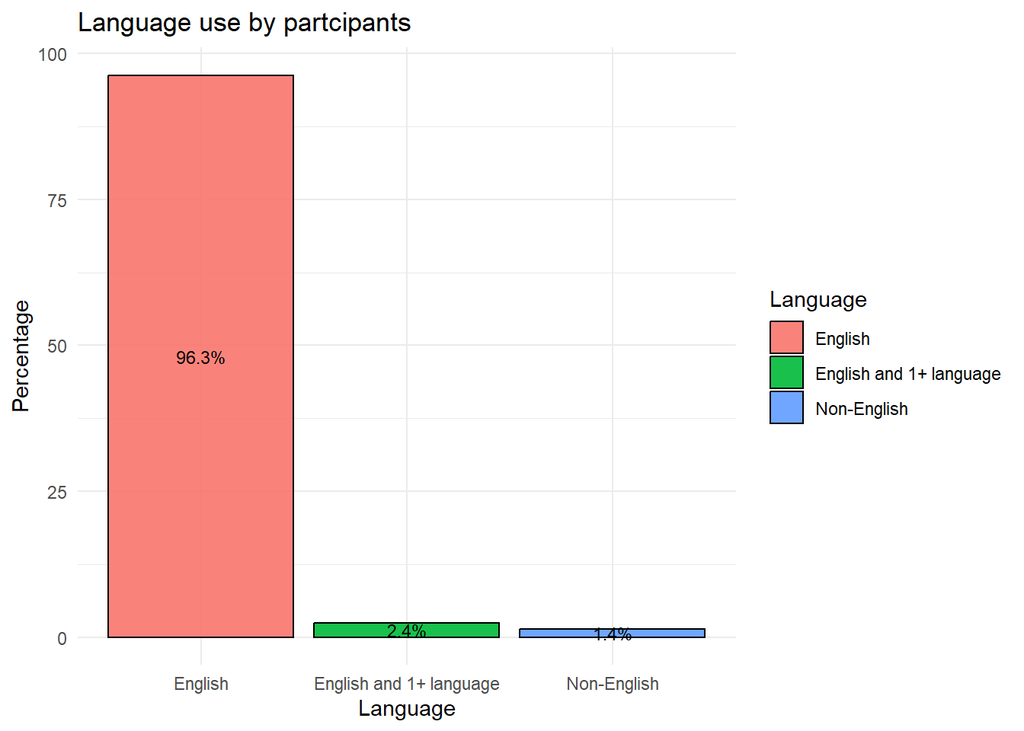

Preferred language used

| 2023 Language | 2023 Percentage | 2024 Language | 2024 Percentage |
| --- | --- | --- | --- |
| Non-English | 1.2 | Non-English | 1.4 |
| English and 1+ language | 2.7 | English and 1+ language | 2.4 |
| English | 96.1 | English | 96.3 |

Language use has remained stable between the years, with English being the most commonly used language by participants.

All languages reported

| 2023 Language | 2023 Count | 2024 Language | 2024 Count |
| --- | --- | --- | --- |
| Arabic | 1 | Arabic | 3 |
| Chinese | 3 | Chinese | 4 |
| English | 660 | English | 921 |
| Farsi | 1 | French | 5 |
| French | 4 | German | 4 |
| German | 3 | Hebrew | 1 |
| Hebrew | 1 | Italian | 1 |
| Korean | 2 | Japanese | 1 |
| Russian | 4 | Korean | 3 |
| Spanish | 5 | Nepeli | 1 |
| Ukrainian | 3 | Polish | 1 |
| Urdu | 1 | Portuguese | 1 |
| Bahasa | 1 | Russian | 6 |
| Kree | 1 | Spanish | 9 |
| NA | NA | Tagalog | 2 |
| NA | NA | Ukrainian | 1 |
| NA | NA | Vietnamese | 2 |

There is a growing number of languages used by SOAK participants, three more languages than in 2023.

### Accessibility Requirements

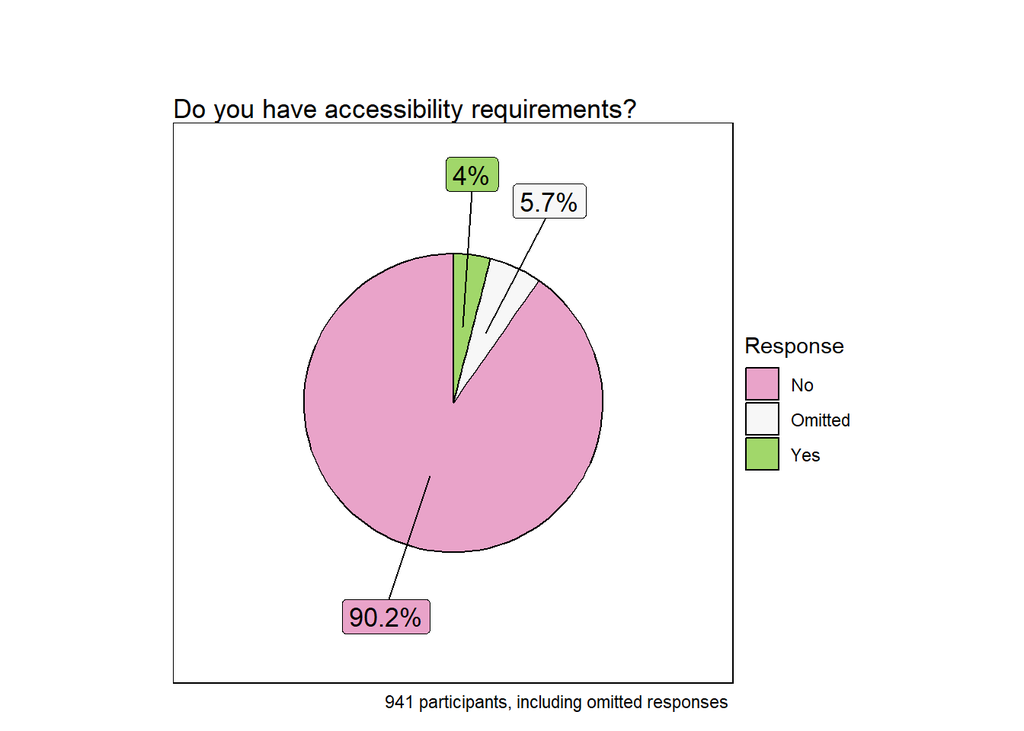

Do you have accessibility requirements?

| Response | 2024 Count | 2024 Percent |
| --- | --- | --- |
| No | 849 | 90.2 |
| Omitted | 54 | 5.7 |
| Yes | 38 | 4.0 |

### Military Status

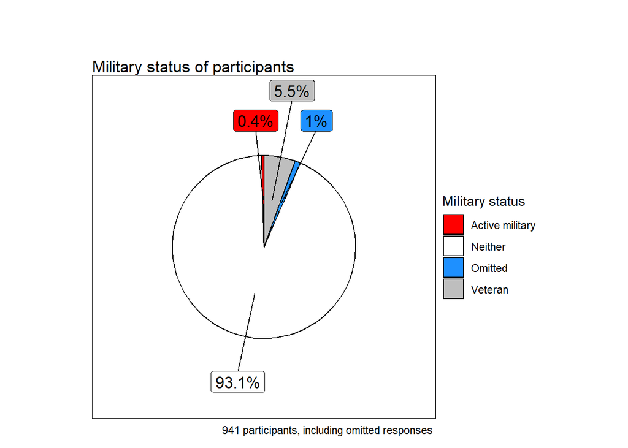

Military service

| Status | 2024 Count | 2024 Percent |
| --- | --- | --- |
| Active military | 4 | 0.4 |
| Neither | 876 | 93.1 |
| Omitted | 9 | 1.0 |
| Veteran | 52 | 5.5 |

According to USA Facts, [Oregon’s Veteran population in 2022 was 7.4%](https://usafacts.org/topics/veterans/state/oregon/), which is higher than the SOAK population.

# Spirituality and Politics

### Political Party Affiliation

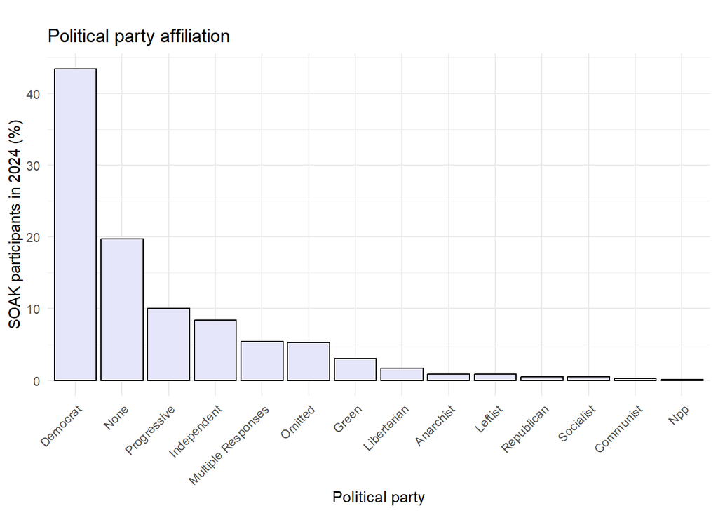

Political party affiliation

| Politics | 2023 Count | 2023 Percent | 2024 Count | 2024 Percent |
| --- | --- | --- | --- | --- |
| Democrat | 296 | 44.2 | 408 | 43.4 |
| None | 150 | 22.4 | 185 | 19.7 |
| Progressive | 71 | 10.6 | 94 | 10.0 |
| Independent | 48 | 7.2 | 79 | 8.4 |
| Multiple responses | 41 | 6.1 | 51 | 5.4 |
| Omitted | 15 | 2.2 | 50 | 5.3 |
| Green | 20 | 3.0 | 28 | 3.0 |
| Libertarian | 9 | 1.3 | 16 | 1.7 |
| Anarchist | 4 | 0.6 | 8 | 0.9 |
| Leftist | NA | NA | 8 | 0.9 |
| Republican | 2 | 0.3 | 5 | 0.5 |
| Socialist | 1 | 0.1 | 5 | 0.5 |
| Communist | 3 | 0.4 | 3 | 0.3 |
| NPP | NA | NA | 1 | 0.1 |
| Democratic Socialist | 2 | 0.3 | NA | NA |
| Libertarian Socialist | 1 | 0.1 | NA | NA |
| Radical | 1 | 0.1 | NA | NA |
| Unsure | 5 | 0.7 | NA | NA |
| Working Families | 1 | 0.1 | NA | NA |

The table is organized in descending order by 2024’s percent. The most commonly reported political party affiliation was Democrat (43.4%), with no political affiliation coming in second most. Progressive was third most common. These 3 ranked the same in 2023. In 2023, [64.9% of Burners reported Democrat as their party affiliation](https://blackrockcitycensus.org/sociodemo#political-party-affiliation), followed by None or unaffiliated.

### Religion and Spirituality

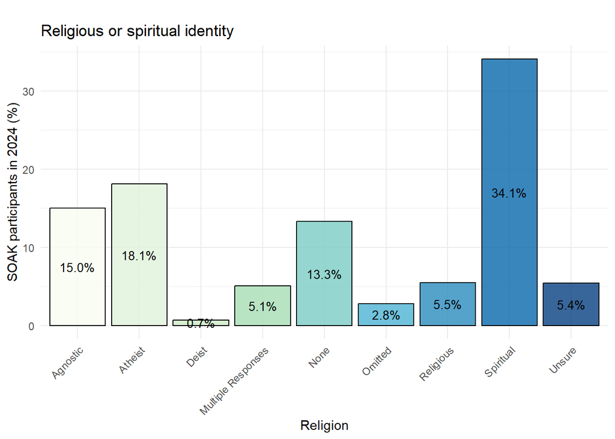

Religious or spiritual identity

| Religion | 2023 Count | 2023 Percent | 2024 Count | 2024 Percent |
| --- | --- | --- | --- | --- |
| Spiritual | 224 | 33.4 | 321 | 34.1 |
| Atheist | 112 | 16.7 | 170 | 18.1 |
| Agnostic | 94 | 14.0 | 141 | 15.0 |
| None | 96 | 14.3 | 125 | 13.3 |
| Religious | 36 | 5.4 | 52 | 5.5 |
| Unsure | 45 | 6.7 | 51 | 5.4 |
| Multiple responses | 52 | 7.8 | 48 | 5.1 |
| Omitted | 9 | 1.3 | 26 | 2.8 |
| Deist | 2 | 0.3 | 7 | 0.7 |

The table is organized in descending order by 2024’s percent. Spiritual was the highest reported religious or spiritual identity in 2024, same as in 2023. Athiest and agnostic were the 2nd and 3rd most commonly reported identity, respectively. This matches how Burners reported their religious and spiritual beliefs, with [spiritual coming in at 47.4%, atheist at 23.1%, and agnostic at 16.2%](https://blackrockcitycensus.org/sociodemo#spirituality).

# Sexuality and Relationships

### Sexual Orientation

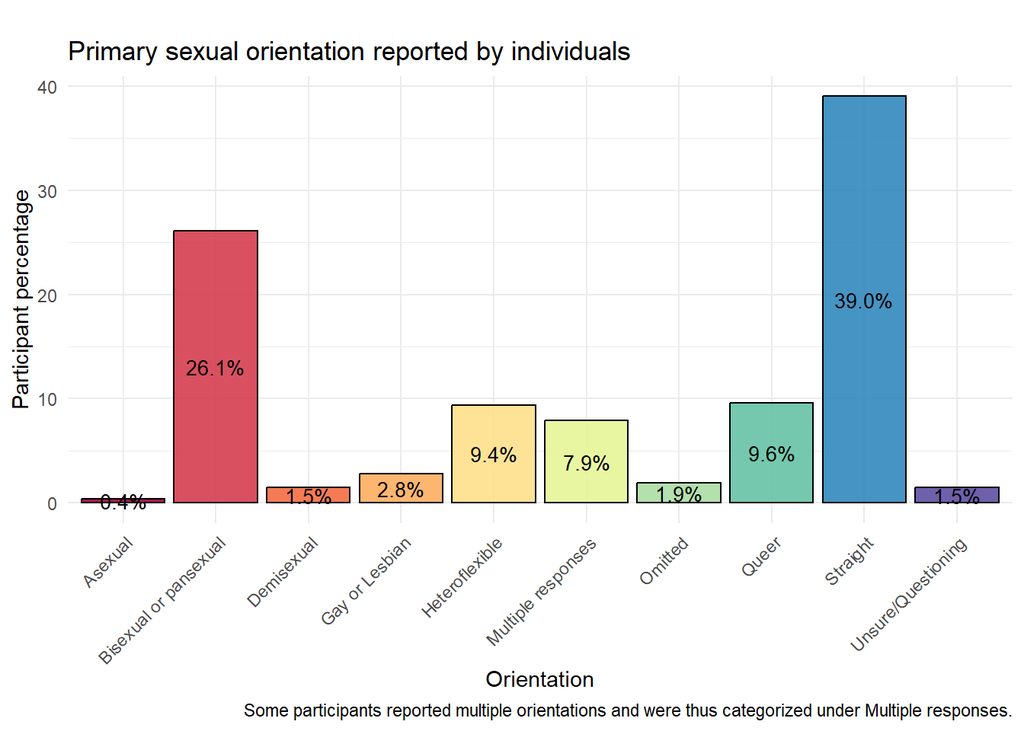

Straight was the most commonly reported sexual orientation in an individual (39.0%) followed by bisexual or pansexual (26.1%) in 2024. The grpah is organized alphabetically and those who reported multiple orientations were clustered into the “Multiple responses” category. The numbers account for the total times an orientation was reported based on the population total. A more granular depiction of the data is further in this section.

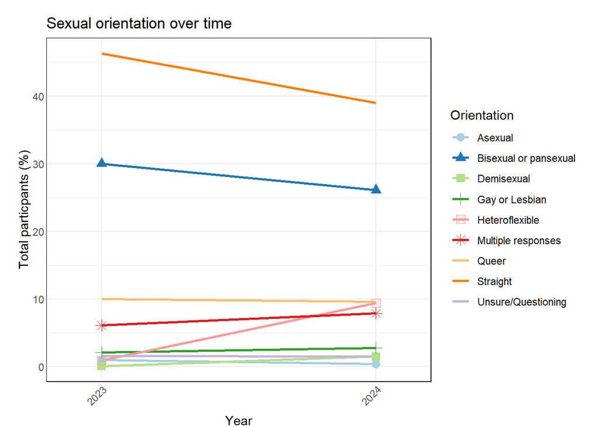

Sexual orientation

| Orientation | 2023 Count | 2023 Percent | 2024 Count | 2024 Percent |
| --- | --- | --- | --- | --- |
| Straight | 310 | 46.3 | 367 | 39.0 |
| Bisexual or pansexual | 201 | 30.0 | 246 | 26.1 |
| Queer | 67 | 10.0 | 90 | 9.6 |
| Heteroflexible | 6 | 0.9 | 88 | 9.4 |
| Multiple responses | 41 | 6.1 | 74 | 7.9 |
| Gay or Lesbian | 14 | 2.1 | 26 | 2.8 |
| Omitted | 12 | 1.8 | 18 | 1.9 |
| Demisexual | 1 | 0.1 | 14 | 1.5 |
| Unsure/Questioning | 11 | 1.6 | 14 | 1.5 |
| Asexual | 7 | 1.0 | 4 | 0.4 |

The three most commonly reported sexual orientations did not changes across years. In 2024, “heteroflexible” was added to the survey in response to the write-in option used in 2023. This category saw the largest increase from 0.9% to 9.4%. According to an Oregon Live article, [the Oregon LGBTQ+ population is 7.8%](https://www.oregonlive.com/living/2023/12/oregon-has-more-lgbtq-residents-per-capita-than-any-other-state-in-the-us-report.html), with the national population at about 5.6%. That said, the LGBTQ+ population at SOAK is quite large.

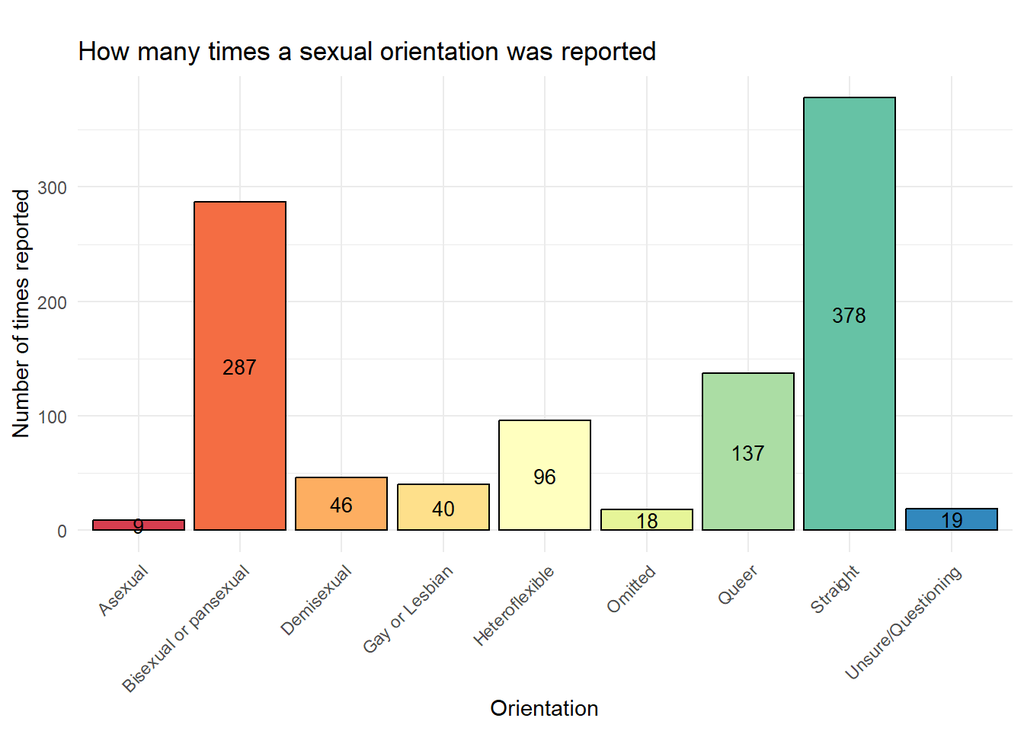

Percent in table is calculated by the count divided by the number of total responses

| Orientation | Count | Percent |
| --- | --- | --- |
| Straight | 378 | 36.7 |
| Bisexual or pansexual | 287 | 27.9 |
| Queer | 137 | 13.3 |
| Heteroflexible | 96 | 9.3 |
| Demisexual | 46 | 4.5 |
| Gay or Lesbian | 40 | 3.9 |
| Unsure/Questioning | 19 | 1.8 |
| Omitted | 18 | 1.7 |
| Asexual | 9 | 0.9 |

Here we see how many times a sexual orientation was reported. Since folks occasionally selected more than one orientation, we can see how often different orientations were selected instead of only accounting for the individual single identity (or multiple identities) as plotted before. This more detailed look at the data shows how many times each item was selected, thus showing some differences in reporting.

### Relationship Orientation

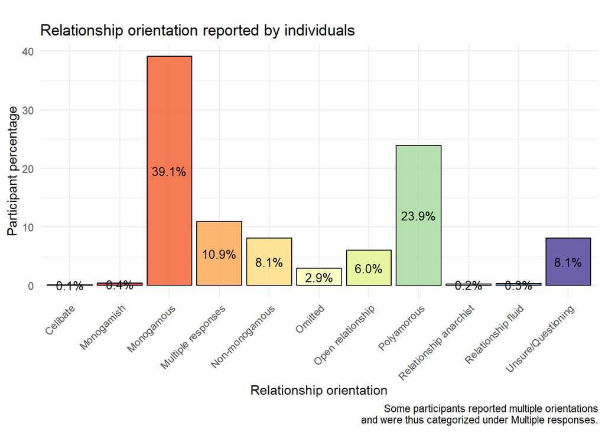

Monogamous was the most common relationship orientation at 39.1%, followed by polyamorous at 23.9%, then those who reported multiple orientations. A more detailed look at responses is below.

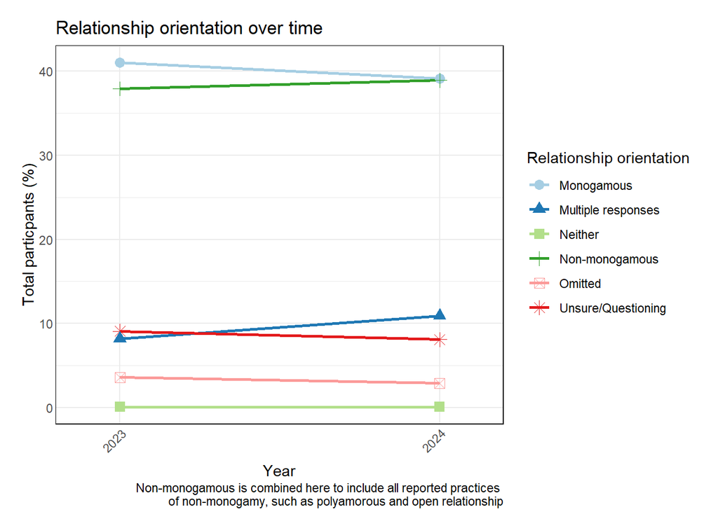

Primary relationship orientation

| Orientation | 2023 Count | 2023 Percent | 2024 Count | 2024 Percent |
| --- | --- | --- | --- | --- |
| Monogamous | 275 | 41.0 | 368 | 39.1 |
| Non-monogamous | 254 | 37.9 | 366 | 38.9 |
| Multiple responses | 55 | 8.2 | 103 | 10.9 |
| Unsure/Questioning | 61 | 9.1 | 76 | 8.1 |
| Omitted | 24 | 3.6 | 27 | 2.9 |
| Neither | 1 | 0.1 | 1 | 0.1 |

All practices of the larger “non-monogamy” umbrella were combined for the above longitudinal graph and table to simplify our understanding of SOAK participants.Aromantic and celibate were categorized under “Neither”.

A [2023 YouGov Poll](https://d3nkl3psvxxpe9.cloudfront.net/documents/Monogamy_NonMonogamy_Relationships_Toplines_crosstabs.pdf) found that 55% of Americans align as monogamous, compared to SOAK’s 39.1%. This is a small decrease from 2023, where 41% were monogamous.

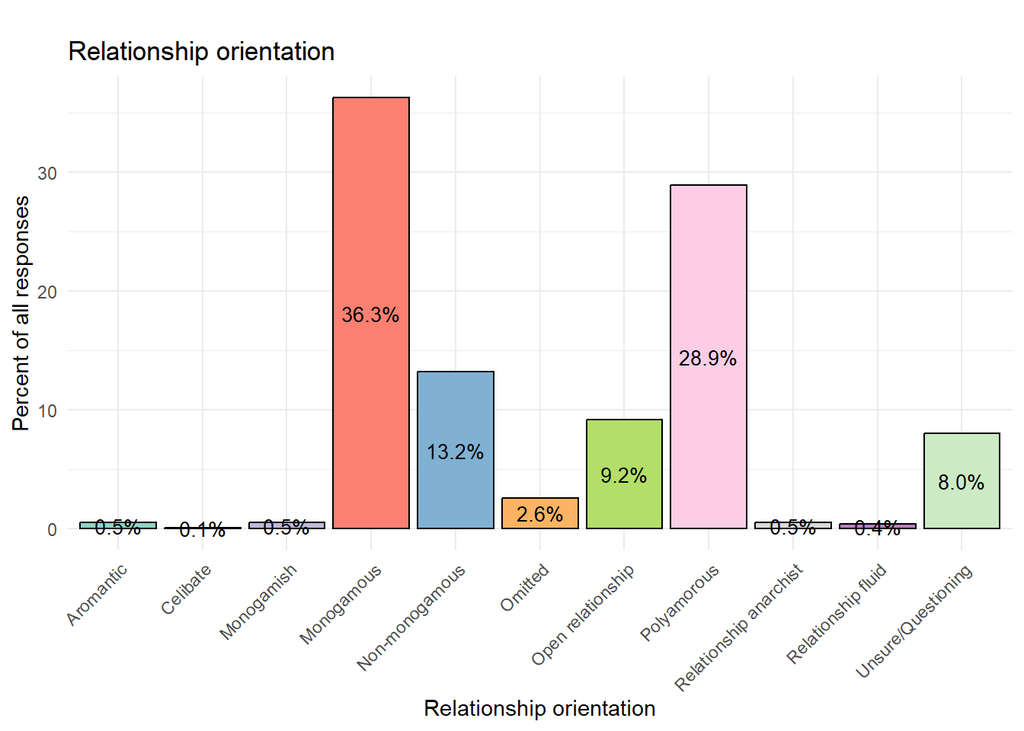

The number of times a relationship orientation was reported across all participants, totaling 1070 responses

| Relationship | Count | Percent |
| --- | --- | --- |
| Monogamous | 388 | 36.3 |
| Polyamorous | 309 | 28.9 |
| Non-monogamous | 141 | 13.2 |
| Open relationship | 98 | 9.2 |
| Unsure/Questioning | 86 | 8.0 |
| Omitted | 28 | 2.6 |
| Aromantic | 5 | 0.5 |
| Monogamish | 5 | 0.5 |
| Relationship anarchist | 5 | 0.5 |
| Relationship fluid | 4 | 0.4 |
| Celibate | 1 | 0.1 |

Here we see how many times a relationship orientation was reported. Since folks occasionally selected more than one, we can see how often different orientations were selected, thus showing some differences in reporting.

# Event Preferences and Practices

## Transportation and Lodging

### Arrival Time

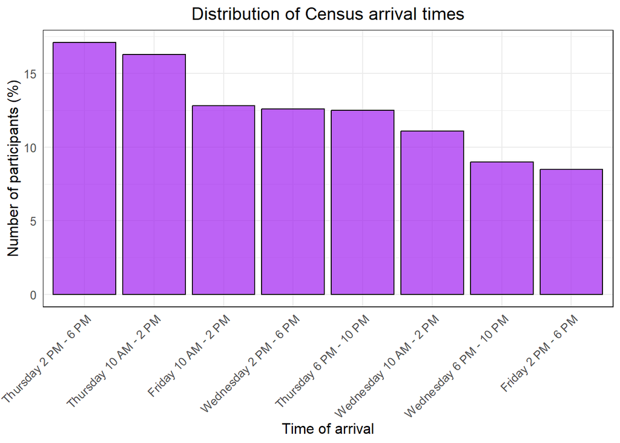

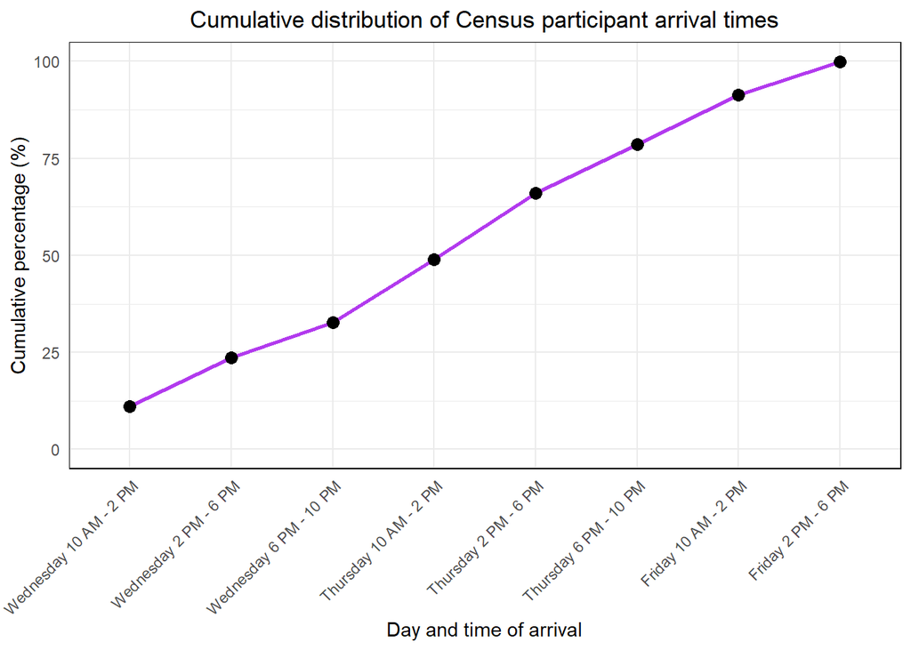

Date and time of arrival

| Arrival | 2024 Count | 2024 Percent |
| --- | --- | --- |
| Wednesday 10 AM - 2 PM | 104 | 11.1 |
| Wednesday 2 PM - 6 PM | 119 | 12.6 |
| Wednesday 6 PM - 10 PM | 85 | 9.0 |
| Thursday 10 AM - 2 PM | 153 | 16.3 |
| Thursday 2 PM - 6 PM | 161 | 17.1 |
| Thursday 6 PM - 10 PM | 118 | 12.5 |
| Friday 10 AM - 2 PM | 120 | 12.8 |
| Friday 2 PM - 6 PM | 80 | 8.5 |
| Omitted | 1 | 0.1 |

### Transportation Method

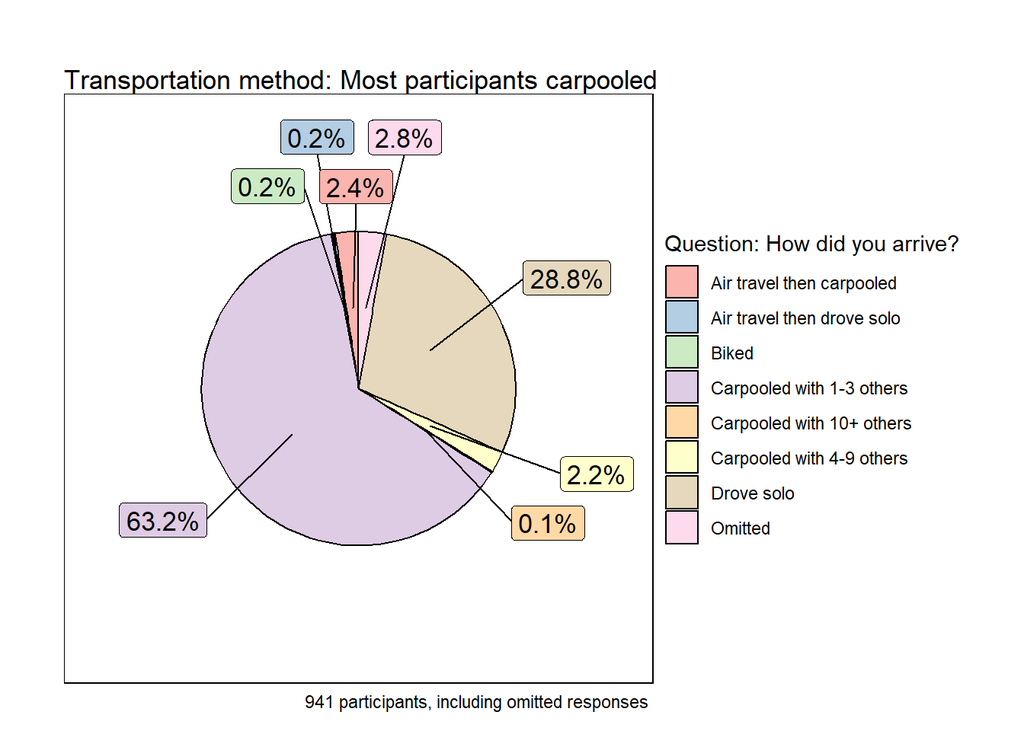

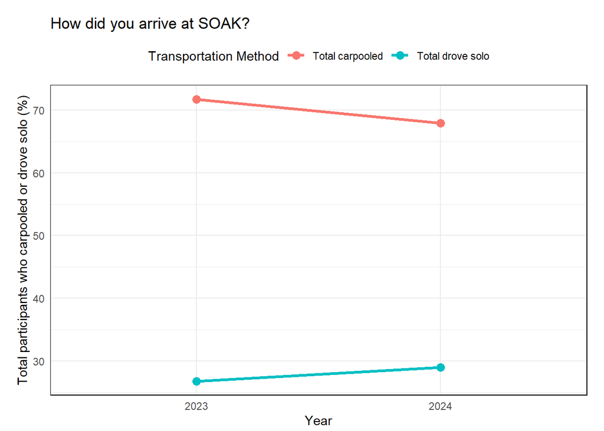

How did you arrive at SOAK?

| 2023 Transportation method | 2023 Count | 2023 Percent | 2024 Transportation method | 2024 Count | 2024 Percent |
| --- | --- | --- | --- | --- | --- |
| Total carpooled | 480 | 71.7 | Total carpooled | 640 | 67.9 |
| Carpooled with 1-3 others | 456 | 68.1 | Carpooled with 1-3 others | 595 | 63.2 |
| Total drove solo | 180 | 26.8 | Total drove solo | 273 | 29.0 |
| Drove solo | 179 | 26.7 | Drove solo | 271 | 28.8 |
| Omitted | 10 | 1.5 | Omitted | 26 | 2.8 |
| Air travel then carpooled | 6 | 0.9 | Air travel then carpooled | 23 | 2.4 |
| Carpooled with 4-9 others | 16 | 2.4 | Carpooled with 4-9 others | 21 | 2.2 |
| Air travel then drove solo | 1 | 0.1 | Air travel then drove solo | 2 | 0.2 |
| NA | NA | NA | Biked | 2 | 0.2 |
| Carpooled with 10+ others | 2 | 0.3 | Carpooled with 10+ others | 1 | 0.1 |

### Sleeping Arrangement and RV Opinions

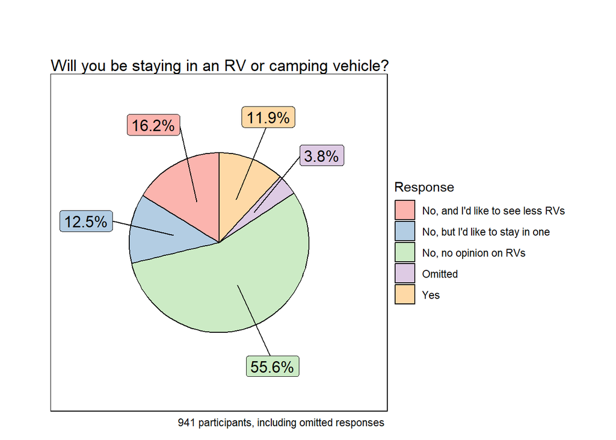

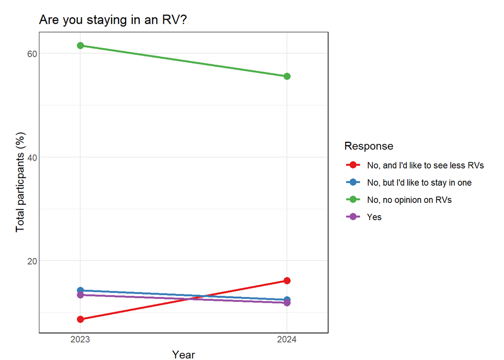

Will you be staying in an RV or camping vehicle?

| Response | 2023 Count | 2023 Percent | 2024 Count | 2024 Percent |
| --- | --- | --- | --- | --- |
| No, no opinion on RVs | 412 | 61.5 | 523 | 55.6 |
| No, and I’d like to see less RVs | 58 | 8.7 | 152 | 16.2 |
| No, but I’d like to stay in one | 96 | 14.3 | 118 | 12.5 |
| Yes | 90 | 13.4 | 112 | 11.9 |
| Omitted | 14 | 2.1 | 36 | 3.8 |

This question bakes in an opinion in addition to gaining information on how participants sleep at SOAK. Only 11.9% of participants stayed in an RV or camping vehicle, which is a decrease from the previous year. Of those who did not stay in RVs, most did not have an opinion on their presence at SOAK, although more people reported wanting to see less of them than 2023.

### Ticket Acquisition

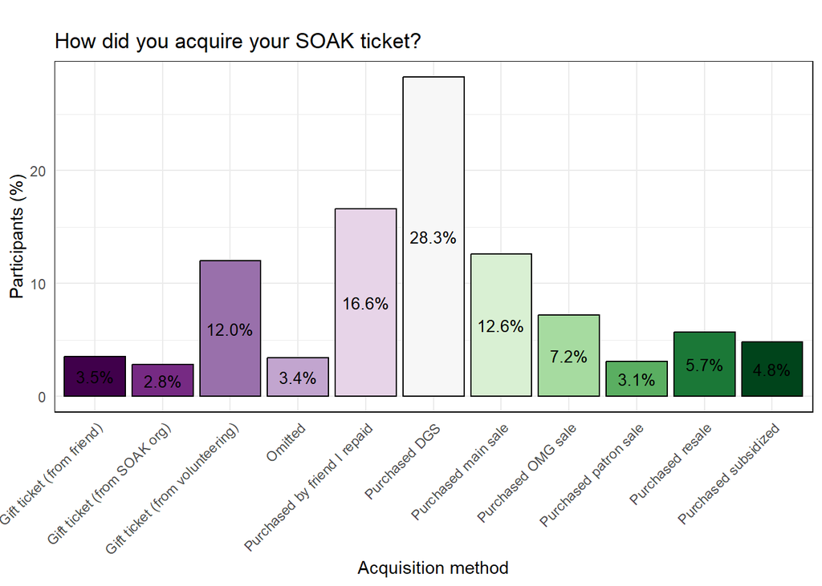

How did you acquire your SOAK ticket?

| Ticket | 2023 Count | 2023 Percent | 2024 Count | 2024 Percent |
| --- | --- | --- | --- | --- |
| Purchased DGS | 162 | 24.2 | 266 | 28.3 |
| Purchased by friend I repaid | 114 | 17.0 | 156 | 16.6 |
| Purchased main sale | 128 | 19.1 | 119 | 12.6 |
| Gift ticket (from volunteering) | 59 | 8.8 | 113 | 12.0 |
| Purchased OMG sale | 53 | 7.9 | 68 | 7.2 |
| Purchased resale | 43 | 6.4 | 54 | 5.7 |
| Purchased subsidized | 21 | 3.1 | 45 | 4.8 |
| Gift ticket (from friend) | 31 | 4.6 | 33 | 3.5 |
| Omitted | 18 | 2.7 | 32 | 3.4 |
| Purchased patron sale | 24 | 3.6 | 29 | 3.1 |
| Gift ticket (from SOAK org) | 17 | 2.5 | 26 | 2.8 |

The above table is organized in descending order of 2024 Percent values. Ticket acquisition for SOAK remained mostly done through directed group sales (DGS) at 28.3% in 2024 which was the same in 2023, followed by repaying a friend at 16.6%, then purchasing through the main sale at 12.6%. These 2 methods swapped places in 2024. The largest change occurred in main sale acquisition (dropping 6.5%), whereas volunteer gift tickets went up by 3.2%.

Subsidized tickets (Burning Man’s version of the ticket aid program) accounted for 4.8%.

### SOAK Location

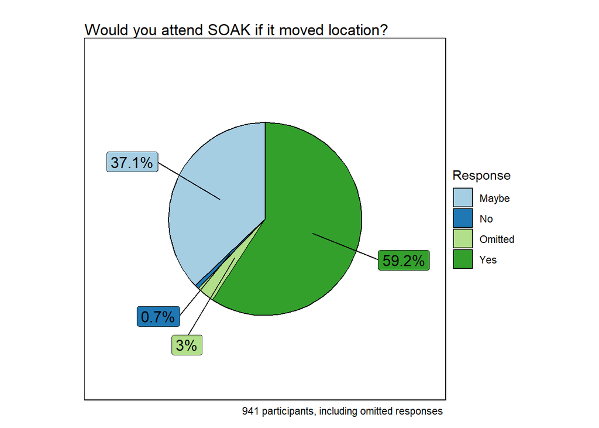

Would you attended SOAK if it moved location?

| Response | 2023 Count | 2023 Percent | 2024 Count | 2024 Percent |
| --- | --- | --- | --- | --- |
| Maybe | 229 | 34.2 | 349 | 37.1 |
| No | 3 | 0.4 | 7 | 0.7 |
| Omitted | 6 | 0.9 | 28 | 3.0 |
| Yes | 432 | 64.5 | 557 | 59.2 |

Most participants (59.2%) would follow SOAK if it moved. Cautiously, 37.1% might attend SOAK if it moved. Perhaps location-dependent? Only a small fraction, 0.7%, claimed they would not attend SOAK if it left Justesen Ranch in Tygh Valley. These values are relatively consistent with 2023.